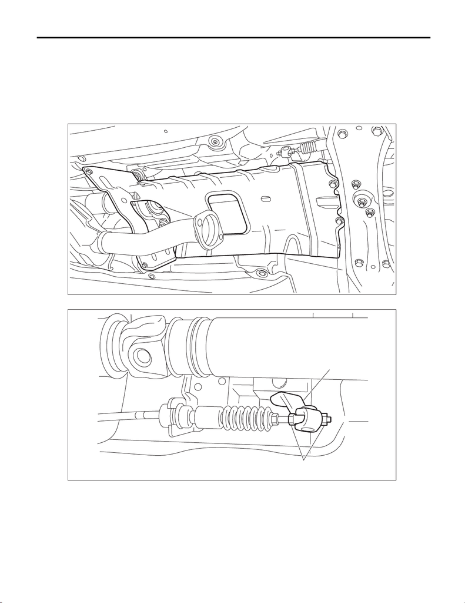

CS-24

Select Lever

CONTROL SYSTEMS

3. Select Lever

A: REMOVAL

1) Shift the select lever to “N” range.

2) Disconnect the ground terminal from battery sensor. <Ref. to NT-5, BATTERY, NOTE, Note.>

3) Lift up the vehicle.

4) Remove the center exhaust pipe (rear). <Ref. to EX(w/o STI)-35, REMOVAL, Center Exhaust Pipe.>

5) Remove the center exhaust cover.

6) Disconnect the cable from the arm COMPL.

(A) Adjusting nut (B) Arm COMPL

AT-07743

CS-01655

(B)

(A)

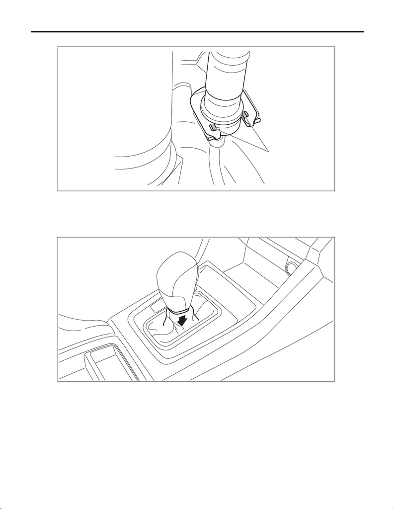

CS-25

Select Lever

CONTROL SYSTEMS

7) Raise the claw of clamp and remove the cable.

8) Lower the vehicle.

9) Shift the select lever to “N” range.

10) Lower the boot assembly vertically toward the lever.

(A) Claw

CS-01536

(A)

CS-01777

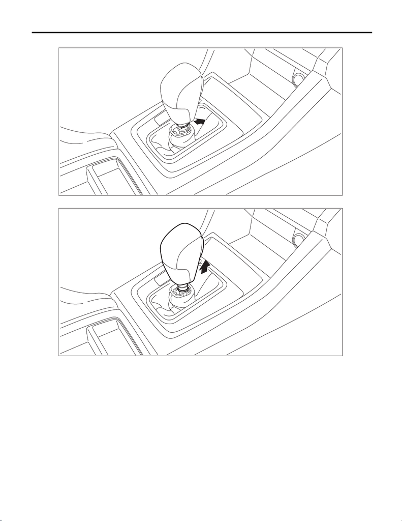

CS-26

Select Lever

CONTROL SYSTEMS

11) Remove the clamp grip pin.

12) Remove the grip assembly.

13) Remove the console box assembly. <Ref. to EI-67, REMOVAL, Console Box.>

14) Remove the cover - shift lever. <Ref. to EI-67, REMOVAL, Console Box.>

15) Remove the panel center LWR LH and RH. <Ref. to EI-67, REMOVAL, Console Box.>

CS-01778

CS-01779

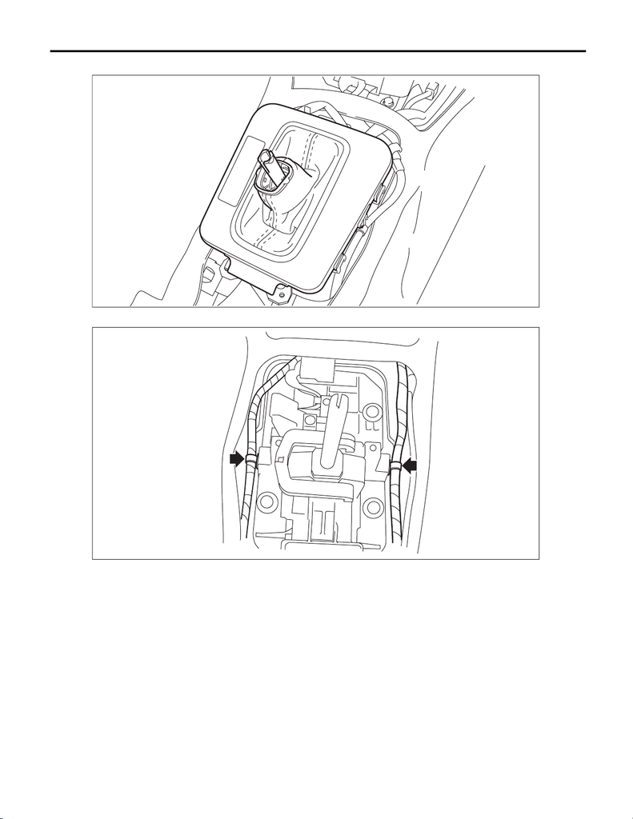

CS-27

Select Lever

CONTROL SYSTEMS

16) Disconnect the connector, and remove the indicator assembly.

17) Remove the harness clips.

CS-01782

CS-01668

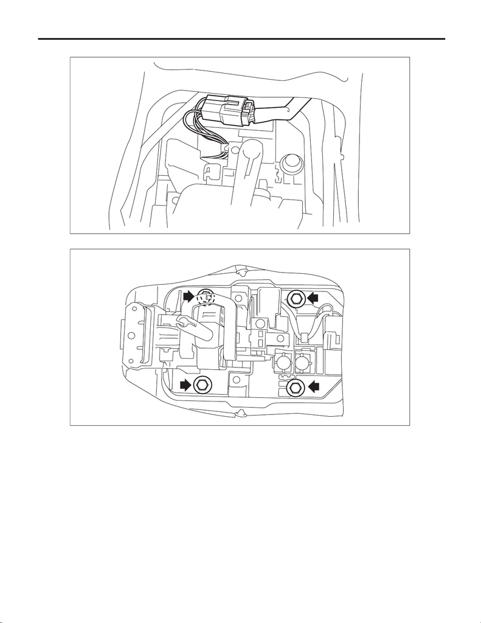

CS-28

Select Lever

CONTROL SYSTEMS

18) Disconnect the harness connector.

19) Remove the select lever assembly.

CS-01501

CS-01669

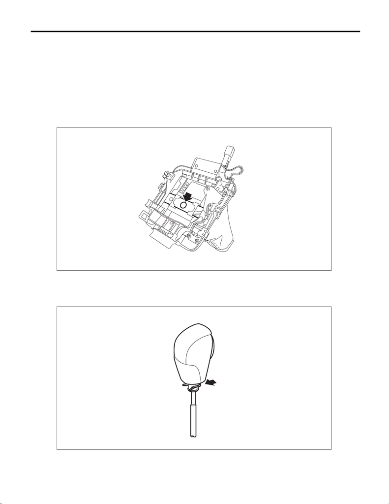

CS-29

Select Lever

CONTROL SYSTEMS

B: INSTALLATION

1) Install the select lever assembly after setting it to the vehicle body.

Tightening torque:

18 N·m (1.8 kgf-m, 13.3 ft-lb)

2) Connect the harness connector.

3) Install the harness clip to the select lever assembly.

4) Shift the select lever to “N” range.

5) Install the indicator assembly, then connect the connector.

NOTE:

Insert the select lever through the blind hole sufficiently.

6) Install the panel center LWR LH and RH. <Ref. to EI-68, INSTALLATION, Console Box.>

7) Install the cover - shift lever. <Ref. to EI-68, INSTALLATION, Console Box.>

8) Install the console box assembly. <Ref. to EI-68, INSTALLATION, Console Box.>

9) Accessing from the button side of the grip, attach the clamp grip pin.

CS-01847

CS-01434

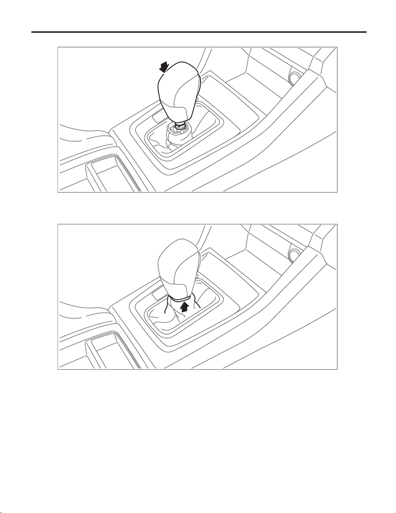

CS-30

Select Lever

CONTROL SYSTEMS

10) Insert the grip assembly to the select lever and press it down until a click is heard.

11) Securely install the boot assembly.

NOTE:

After installation, check that the boot assembly does not come off.

12) After installation of grip, check the following points.

• The grip will not come off.

• The button on the grip operates normally.

CS-01781

CS-01780

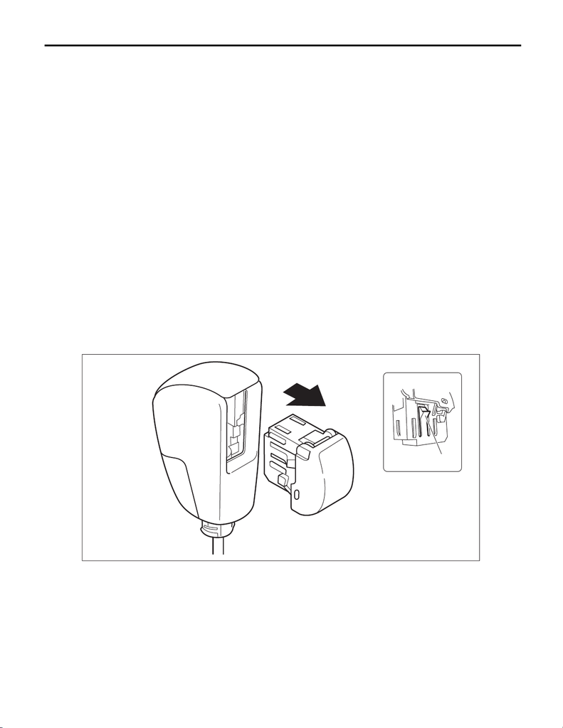

CS-31

Select Lever

CONTROL SYSTEMS

13) Shift the select lever to “N” range.

14) Lift up the vehicle.

15) Secure the cable to the bracket. <Ref. to CS-44, INSTALLATION, Select Cable.>

16) Adjust the select cable position. <Ref. to CS-47, ADJUSTMENT, Select Cable.>

17) After adjustment, confirm that the select lever operates properly at all range positions using the shift lock

release button.

NOTE:

According to the select lever operation, confirm that the indicator positions are shown correctly.

18) Install the center exhaust cover.

Tightening torque:

18 N·m (1.8 kgf-m, 13.3 ft-lb)

19) Install the center exhaust pipe (rear). <Ref. to EX(w/o STI)-41, INSTALLATION, Center Exhaust Pipe.>

20) Lower the vehicle.

21) Connect the ground terminal to battery sensor. <Ref. to NT-5, BATTERY, NOTE, Note.>

22) Inspect the following items. If a malfunction is found in the inspection, adjust the select cable or inhibitor

switch.

(1) The shift lock operates normally. <Ref. to CS-13, SHIFT LOCK OPERATION, INSPECTION, AT Shift

Lock Control System.>

(2) Engine starts when the select lever is in “P” or “N” range, but not in other ranges.

(3) Back-up light illuminates when the select lever is in the “R” range, but not in other ranges.

(4) Select lever and indicator positions are matched.

C: DISASSEMBLY

1. GRIP ASSY

1) Remove the button assembly_AT.

2) Remove the rod COMPL.

(A) Claw

(A)

CS-01429

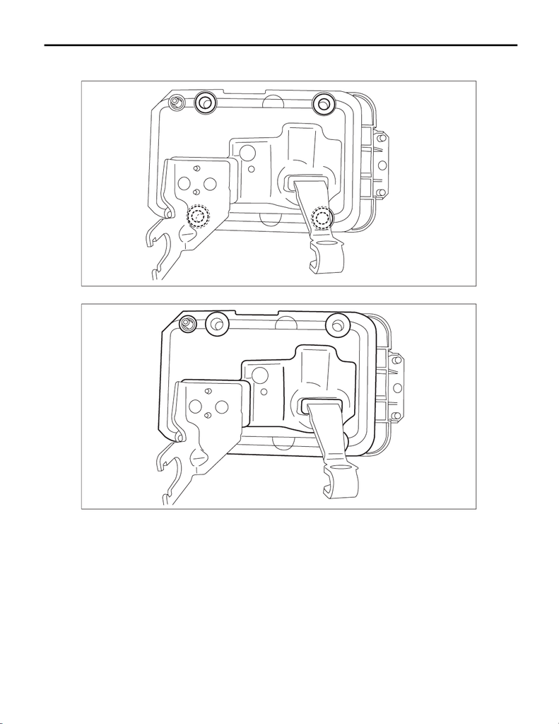

CS-32

Select Lever

CONTROL SYSTEMS

2. AT SELECT LEVER ASSEMBLY

1) Remove the spacer plate.

2) Remove the gasket.

CS-01105

CS-01106

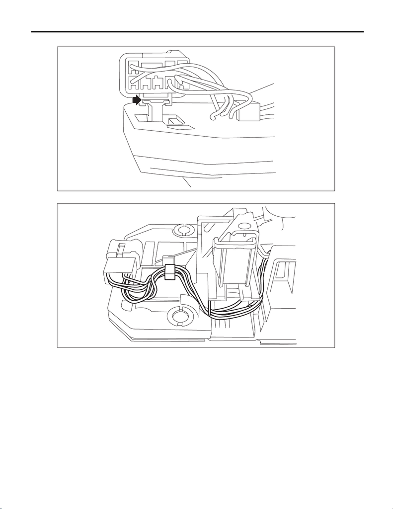

CS-33

Select Lever

CONTROL SYSTEMS

3) Insert a flat tip screwdriver with a thin tip under the connector and disconnect the harness connector.

4) Remove the harness.

CS-01107

CS-01625

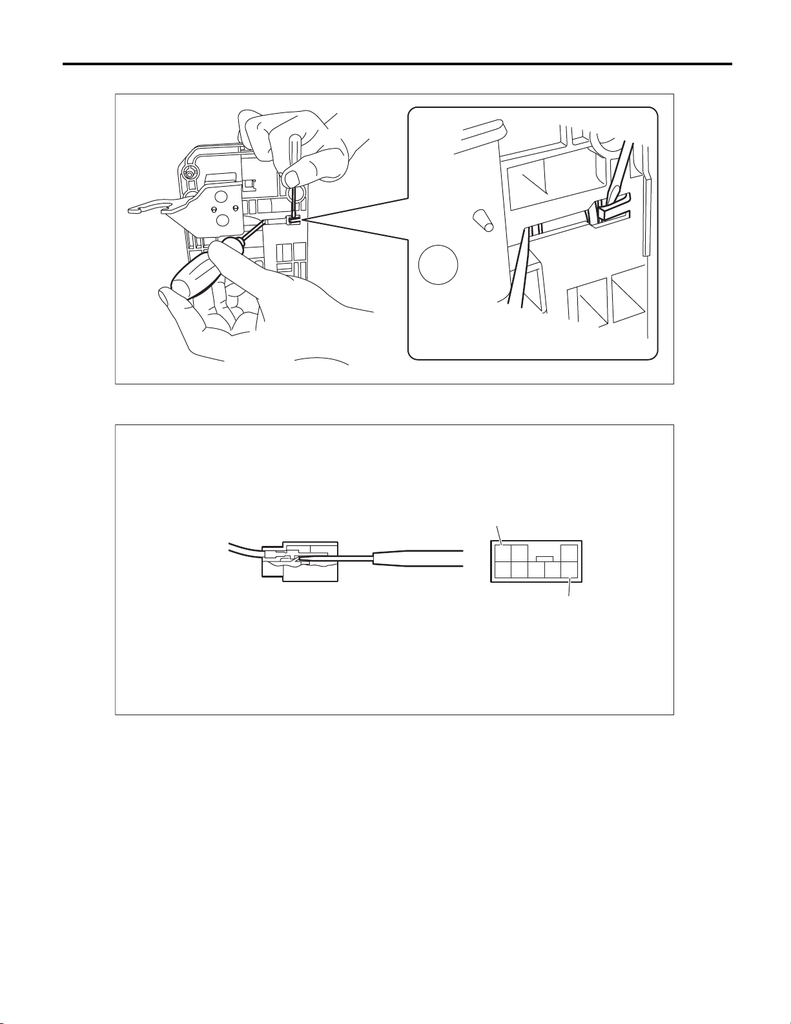

CS-34

Select Lever

CONTROL SYSTEMS

5) Raise the claw with a flat tip screwdriver with a thin tip and remove the solenoid unit.

6) Remove the terminal of the solenoid unit using a flat tip precision screwdriver with a tip width of 1.3 mm

(0.05 in) or less, KTC connector terminal tool ECC-1T or equivalent.

(A) Solenoid unit terminals

CS-01109

CS-01110

3

87

21

65

4

(A)

(A)

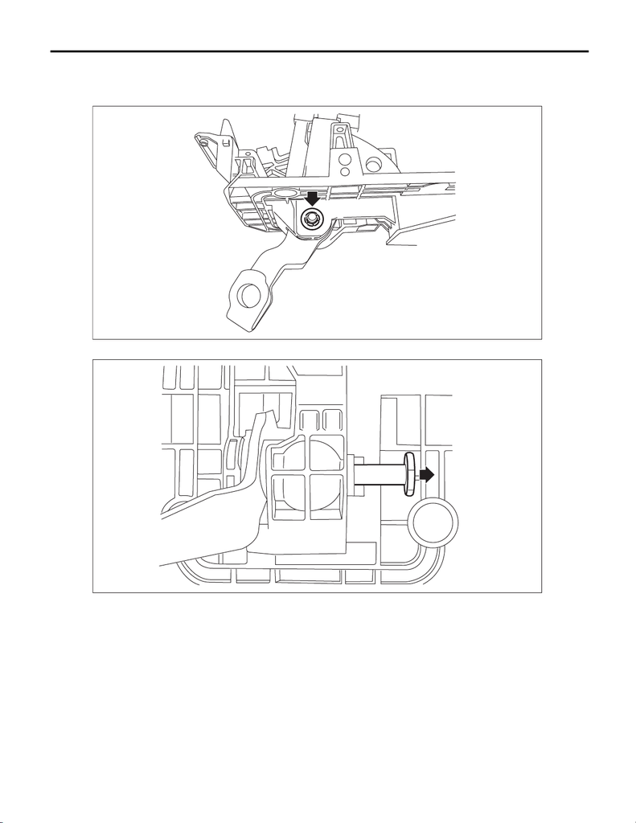

CS-35

Select Lever

CONTROL SYSTEMS

7) Remove the clamp push nut.

NOTE:

Replace the clamp push nut with a new part.

8) Pull out shaft control.

CS-01626

CS-01112

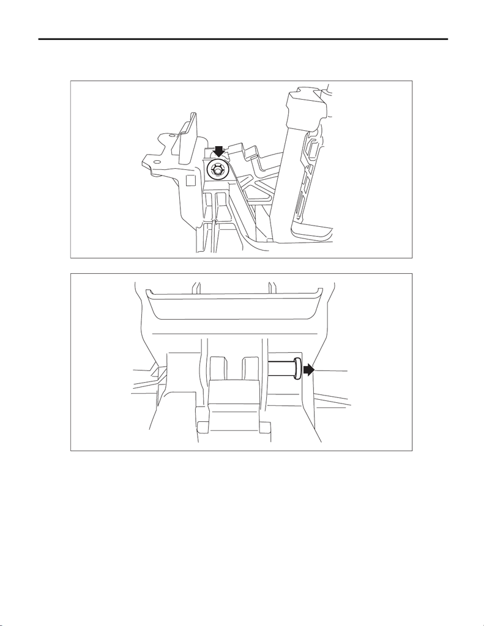

CS-36

Select Lever

CONTROL SYSTEMS

9) Remove the clamp push nut.

NOTE:

Replace the clamp push nut with a new part.

CS-01627

CS-01114

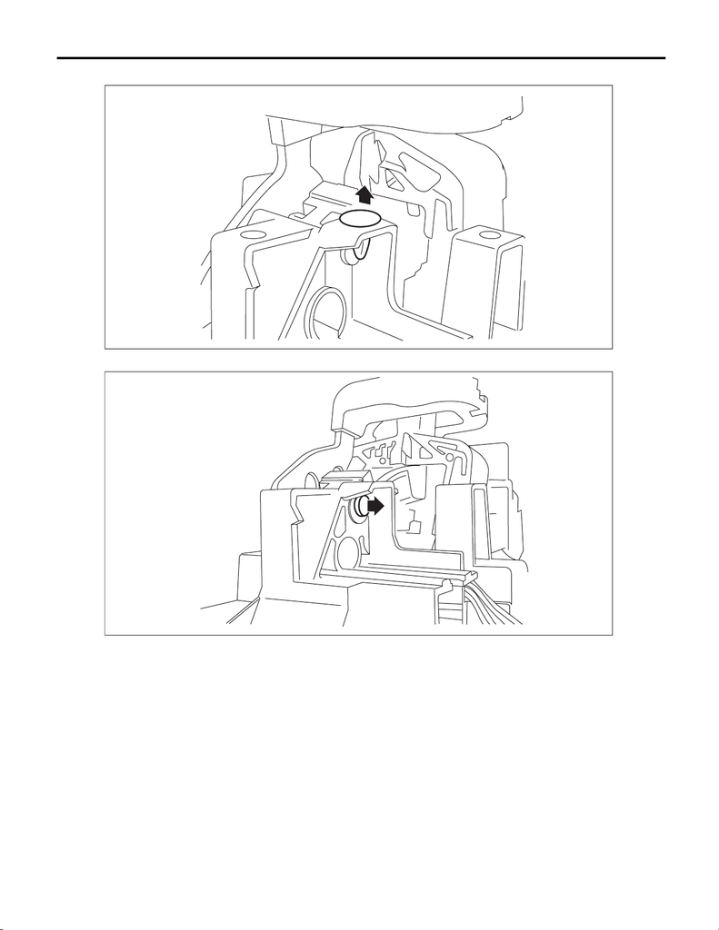

CS-37

Select Lever

CONTROL SYSTEMS

12) Remove the spacer pin guide.

CS-01628

CS-01116

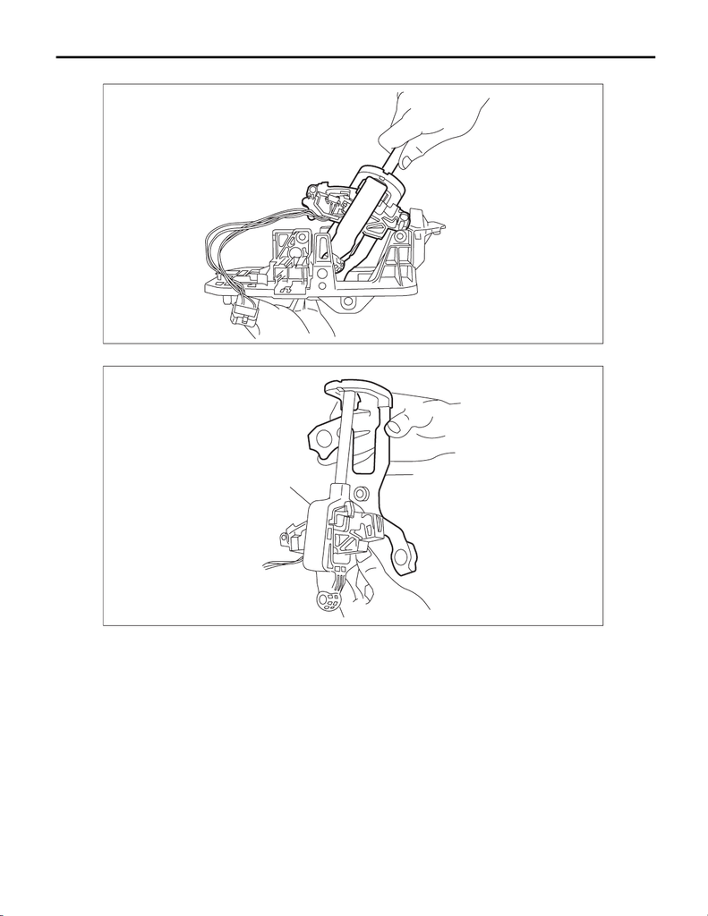

CS-38

Select Lever

CONTROL SYSTEMS

13) Remove the select lever COMPL.

14) Remove the arm COMPL.

(A) Arm COMPL (B) Selector lever COMPL

CS-01629

CS-01411

(A)

(B)

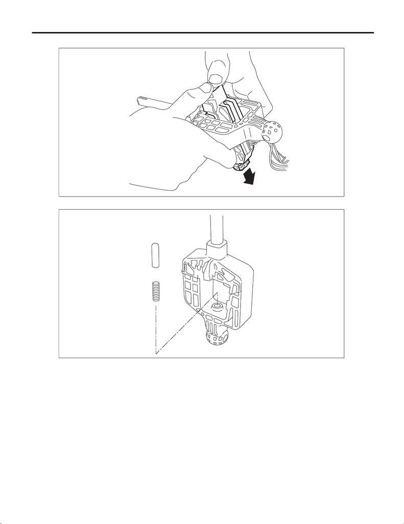

CS-39

Select Lever

CONTROL SYSTEMS

15) Remove the plate guide.

16) Remove the rod detent and the detent spring.

CS-01211

CS-01212

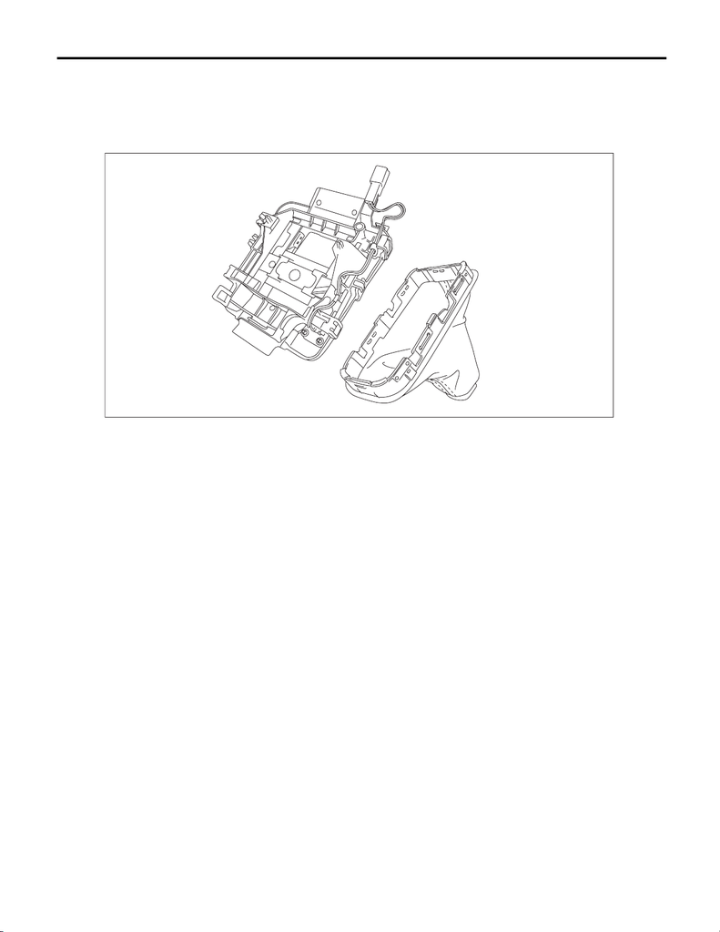

CS-40

Select Lever

CONTROL SYSTEMS

3. INDICATOR ASSY

1) Remove the boot assembly from the indicator assembly.

CAUTION:

When removing the boot assembly, be careful not to damage the boot assembly claws and adjacent

parts.

CS-01835

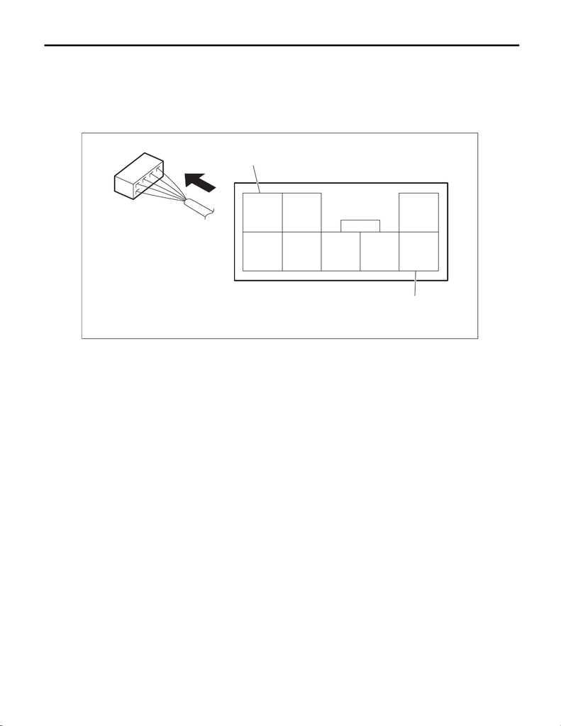

CS-41

Select Lever

CONTROL SYSTEMS

D: ASSEMBLY

1) Clean all the parts before assembly.

2) Apply Multemp D or equivalent to the sliding portion of each part.

3) Assemble in the reverse order of disassembly.

NOTE:

Insert the solenoid unit terminals to the harness connector.

4) After installation, check the following points.

• The select indicator matches the select lever position when the select lever is changed from “P” range to

“D” range.

• The select lever position and the position mark match each other.

• Operating force to move the select lever from “P” to “D” range.

E: INSPECTION

1) Inspect the removed parts by comparing with new parts for deformation, damage and wear. Repair or re-

place if defective.

2) Inspect the select lever assembly operating condition before assembly. Normal if it operates smoothly.

(A) Solenoid unit (color code: blue) (B) Solenoid unit (color code: black)

CS-01551

3

87

21

65

4

(B)

(A)